# Flight Analysis in the U.S.

Evangeline Tan

# Introduction

Every year, nearly 25% of airline flights are delayed or cancelled, costing travellers over $30 billion in lost time and money Flight delays have long been a cause of dissatisfaction in the airline industry, as well as a source of annoyance for passengers and carriers.

Our goal is to use the massive amount of airline data to visualise and study the flight patterns and predict if a flight will be delayed. For this study, both Python and R will be used to investigate 2 years’ worth of data, since two full business cycles are adequate in reducing bias for one cycle.

This notebook aims to look at these questions regarding flight travel:

1. When is the best time of day, day of the week, and time of year to fly to minimise delays?
2. Do older planes suffer more delays?
3. How does the number of people flying between different locations change over time?
4. Can you detect cascading failures as delays in one airport create delays in others?
5. Use the available variables to construct a model that predicts delays.

Data: [Airlines - Harvard Dataverse](https://doi.org/10.7910/DVN/HG7NV7)

# Import data and libraries

```r
library(ggplot2)
library(dplyr)
library(zoo)
library(tidyr)
library("data.table")
library(plyr)
options(warn=-1)

setwd("D:/et4_e/coursework/2021")

# Import & prepare the 2006 and 2007 dataset
df_2006 = fread("2006.csv.bz2")
```

```
|--------------------------------------------------|
|==================================================|
```

```r
df_2007 = fread("2007.csv.bz2")
```

```
|--------------------------------------------------|
|==================================================|
```

```r
mergeddf = rbind(df_2006, df_2007)
airport_df <- read.csv2('airports.csv',sep = ",",header = TRUE)
carrier_df <- read.csv2('carriers.csv',sep = ",",header = TRUE)
planes_df <- read.csv2('D:/et4_e/coursework/2021/plane-data.csv',sep = ",",header = TRUE)
```

# Understanding Data

```r
# Create Date column
mergeddf$date <- as.Date(with(mergeddf, paste(Year, Month, DayofMonth, sep="-")), "%Y-%m-%d")
# Create copy of merged data
merged_df = mergeddf
head(merged_df)
```

| Year | Month | DayofMonth | DayOfWeek | DepTime | CRSDepTime | ArrTime | CRSArrTime | UniqueCarrier | FlightNum | TailNum | ActualElapsedTime | CRSElapsedTime | AirTime | ArrDelay | DepDelay | Origin | Dest | Distance | TaxiIn | TaxiOut | Cancelled | CancellationCode | Diverted | CarrierDelay | WeatherDelay | NASDelay | SecurityDelay | LateAircraftDelay | date |
| --- | --- | --- | --- | --- | --- | --- | --- | --- | --- | --- | --- | --- | --- | --- | --- | --- | --- | --- | --- | --- | --- | --- | --- | --- | --- | --- | --- | --- | --- |
| 2006 | 1 | 11 | 3 | 743 | 745 | 1024 | 1018 | US | 343 | N657AW | 281 | 273 | 223 | 6 | -2 | ATL | PHX | 1587 | 45 | 13 | 0 |  | 0 | 0 | 0 | 0 | 0 | 0 | 2006-01-11 |
| 2006 | 1 | 11 | 3 | 1053 | 1053 | 1313 | 1318 | US | 613 | N834AW | 260 | 265 | 214 | -5 | 0 | ATL | PHX | 1587 | 27 | 19 | 0 |  | 0 | 0 | 0 | 0 | 0 | 0 | 2006-01-11 |
| 2006 | 1 | 11 | 3 | 1915 | 1915 | 2110 | 2133 | US | 617 | N605AW | 235 | 258 | 220 | -23 | 0 | ATL | PHX | 1587 | 4 | 11 | 0 |  | 0 | 0 | 0 | 0 | 0 | 0 | 2006-01-11 |
| 2006 | 1 | 11 | 3 | 1753 | 1755 | 1925 | 1933 | US | 300 | N312AW | 152 | 158 | 126 | -8 | -2 | AUS | PHX | 872 | 16 | 10 | 0 |  | 0 | 0 | 0 | 0 | 0 | 0 | 2006-01-11 |
| 2006 | 1 | 11 | 3 | 824 | 832 | 1015 | 1015 | US | 765 | N309AW | 171 | 163 | 132 | 0 | -8 | AUS | PHX | 872 | 27 | 12 | 0 |  | 0 | 0 | 0 | 0 | 0 | 0 | 2006-01-11 |
| 2006 | 1 | 11 | 3 | 627 | 630 | 834 | 832 | US | 295 | N733UW | 127 | 122 | 108 | 2 | -3 | BDL | CLT | 644 | 6 | 13 | 0 |  | 0 | 0 | 0 | 0 | 0 | 0 | 2006-01-11 |

```r
dim(merged_df)
```

```
[1] 14595137       30
```

There are almost 14.6 million records with 29 variable columns. The columns include the airline and flight details etc. and are mostly time-related (in mins).

```r
summary(merged_df)
```

```
      Year          Month          DayofMonth      DayOfWeek
 Min.   :2006   Min.   : 1.000   Min.   : 1.00   Min.   :1.000
 1st Qu.:2006   1st Qu.: 4.000   1st Qu.: 8.00   1st Qu.:2.000
 Median :2007   Median : 7.000   Median :16.00   Median :4.000
 Mean   :2007   Mean   : 6.538   Mean   :15.73   Mean   :3.942
 3rd Qu.:2007   3rd Qu.:10.000   3rd Qu.:23.00   3rd Qu.:6.000
 Max.   :2007   Max.   :12.000   Max.   :31.00   Max.   :7.000

    DepTime         CRSDepTime      ArrTime         CRSArrTime
 Min.   :   1     Min.   :   0   Min.   :   1     Min.   :   0
 1st Qu.: 930     1st Qu.: 930   1st Qu.:1108     1st Qu.:1115
 Median :1329     Median :1324   Median :1515     Median :1520
 Mean   :1340     Mean   :1331   Mean   :1484     Mean   :1496
 3rd Qu.:1732     3rd Qu.:1720   3rd Qu.:1911     3rd Qu.:1906
 Max.   :2930     Max.   :2359   Max.   :2955     Max.   :2400
 NA's   :282682                  NA's   :316047
 UniqueCarrier        FlightNum      TailNum
 Length:14595137    Min.   :   1   Length:14595137
 Class :character   1st Qu.: 587   Class :character
 Mode  :character   Median :1501   Mode  :character
                    Mean   :2187
                    3rd Qu.:3499
                    Max.   :9619

 ActualElapsedTime CRSElapsedTime       AirTime
 Min.   :   5.0    Min.   :-1240.0   Min.   :-1425.0
 1st Qu.:  75.0    1st Qu.:   77.0   1st Qu.:   54.0
 Median : 108.0    Median :  109.0   Median :   84.0
 Mean   : 126.2    Mean   :  127.2   Mean   :  102.8
 3rd Qu.: 156.0    3rd Qu.:  157.0   3rd Qu.:  131.0
 Max.   :1879.0    Max.   : 1430.0   Max.   : 1958.0
 NA's   :316047    NA's   :998       NA's   :316047
    ArrDelay          DepDelay           Origin
 Min.   :-592.00   Min.   :-1200.00   Length:14595137
 1st Qu.:  -9.00   1st Qu.:   -4.00   Class :character
 Median :  -1.00   Median :    0.00   Mode  :character
 Mean   :   9.45   Mean   :   10.76
 3rd Qu.:  13.00   3rd Qu.:   10.00
 Max.   :2598.00   Max.   : 2601.00
 NA's   :316047    NA's   :282682
```

[output cut: 24 more lines]

```
    NASDelay        SecurityDelay      LateAircraftDelay
 Min.   :   0.000   Min.   :  0.0000   Min.   :   0.000
 1st Qu.:   0.000   1st Qu.:  0.0000   1st Qu.:   0.000
 Median :   0.000   Median :  0.0000   Median :   0.000
 Mean   :   3.687   Mean   :  0.0273   Mean   :   4.813
 3rd Qu.:   0.000   3rd Qu.:  0.0000   3rd Qu.:   0.000
 Max.   :1392.000   Max.   :382.0000   Max.   :1366.000

      date
 Min.   :2006-01-01
 1st Qu.:2006-07-08
 Median :2007-01-08
 Mean   :2007-01-04
 3rd Qu.:2007-07-06
 Max.   :2007-12-31
```

```r
str(merged_df)
```

```
Classes ‘data.table’ and 'data.frame':  14595137 obs. of  30 variables:
 $ Year             : int  2006 2006 2006 2006 2006 2006 2006 2006 2006 2006 ...
 $ Month            : int  1 1 1 1 1 1 1 1 1 1 ...
 $ DayofMonth       : int  11 11 11 11 11 11 11 11 11 11 ...
 $ DayOfWeek        : int  3 3 3 3 3 3 3 3 3 3 ...
 $ DepTime          : int  743 1053 1915 1753 824 627 825 942 1239 1642 ...
 $ CRSDepTime       : int  745 1053 1915 1755 832 630 820 945 1245 1645 ...
 $ ArrTime          : int  1024 1313 2110 1925 1015 834 1041 1155 1438 1841 ...
 $ CRSArrTime       : int  1018 1318 2133 1933 1015 832 1021 1148 1445 1845 ...
 $ UniqueCarrier    : chr  "US" "US" "US" "US" ...
 $ FlightNum        : int  343 613 617 300 765 295 349 356 775 1002 ...
 $ TailNum          : chr  "N657AW" "N834AW" "N605AW" "N312AW" ...
 $ ActualElapsedTime: int  281 260 235 152 171 127 136 133 119 119 ...
 $ CRSElapsedTime   : int  273 265 258 158 163 122 121 123 120 120 ...
 $ AirTime          : int  223 214 220 126 132 108 111 121 103 105 ...
```

[output cut: 17 more lines]

# Data Pre-Processing/Cleaning

## Creating sample of entire data

Due to the large dataset requiring more time to execute, we will randomly select 10% of the data for quick analysis.

We then filter the data into Cancelled and Non-cancelled flights.

```r
# Remove original data & take sample (10%) of merged data (save space & load faster)
set.seed(42)
merged_df = sample_frac(merged_df, 0.10, replace = FALSE)
```

```r
# Rename CancellationCode Column
merged_df$CancellationCode <- mapvalues(merged_df$CancellationCode,
                           from = c("A", "B", "C", "D"),
                           to = c("Carrier", "Weather", "National Air System (NAS)", "Security"))

merged_df$Cancelled <- mapvalues(merged_df$Cancelled,
                           from = c(1, 0),
                           to = c("Cancelled", "Not Cancelled"))
merged_df$Diverted <- mapvalues(merged_df$Diverted,
                           from = c(1, 0),
                           to = c("Diverted", "Not Diverted"))
```

```r
# Check for missing values
sum(is.na(merged_df))
```

```
[1] 184149
```

```r
# Missing values per column
sapply(merged_df,function(x)sum(is.na(x)))
```

```
             Year             Month        DayofMonth
                0                 0                 0
        DayOfWeek           DepTime        CRSDepTime
                0             28496                 0
          ArrTime        CRSArrTime     UniqueCarrier
            31764                 0                 0
        FlightNum           TailNum ActualElapsedTime
                0                 0             31764
   CRSElapsedTime           AirTime          ArrDelay
              101             31764             31764
         DepDelay            Origin              Dest
            28496                 0                 0
         Distance            TaxiIn           TaxiOut
                0                 0                 0
        Cancelled  CancellationCode          Diverted
                0                 0                 0
     CarrierDelay      WeatherDelay          NASDelay
                0                 0                 0
    SecurityDelay LateAircraftDelay              date
                0                 0                 0
```

```r
# Check for duplicates
sum(duplicated(merged_df))
```

```
[1] 0
```

```r
distinct(merged_df)
```

| Year | Month | DayofMonth | DayOfWeek | DepTime | CRSDepTime | ArrTime | CRSArrTime | UniqueCarrier | FlightNum | TailNum | ActualElapsedTime | CRSElapsedTime | AirTime | ArrDelay | DepDelay | Origin | Dest | Distance | TaxiIn | TaxiOut | Cancelled | CancellationCode | Diverted | CarrierDelay | WeatherDelay | NASDelay | SecurityDelay | LateAircraftDelay | date |
| --- | --- | --- | --- | --- | --- | --- | --- | --- | --- | --- | --- | --- | --- | --- | --- | --- | --- | --- | --- | --- | --- | --- | --- | --- | --- | --- | --- | --- | --- |
| 2006 | 6 | 30 | 5 | 1926 | 1930 | 2218 | 2042 | DL | 1966 | N910DE | 172 | 72 | 38 | 96 | -4 | DCA | LGA | 214 | 6 | 128 | Not Cancelled |  | Not Diverted | 0 | 0 | 96 | 0 | 0 | 2006-06-30 |
| 2006 | 8 | 21 | 1 | 1750 | 1800 | 2025 | 2009 | XE | 3171 | N14950 | 155 | 129 | 122 | 16 | -10 | STL | IAH | 668 | 10 | 23 | Not Cancelled |  | Not Diverted | 0 | 0 | 16 | 0 | 0 | 2006-08-21 |
| 2006 | 9 | 24 | 7 | 1235 | 1230 | 1337 | 1340 | WN | 2781 | N420 | 62 | 70 | 46 | -3 | 5 | BUR | OAK | 325 | 6 | 10 | Not Cancelled |  | Not Diverted | 0 | 0 | 0 | 0 | 0 | 2006-09-24 |
| 2007 | 4 | 12 | 4 | 1119 | 1113 | 1444 | 1355 | AS | 447 | N315AS | 205 | 162 | 175 | 49 | 6 | PSP | SEA | 987 | 5 | 25 | Not Cancelled |  | Not Diverted | 6 | 0 | 43 | 0 | 0 | 2007-04-12 |
| 2006 | 6 | 3 | 6 | 1827 | 1837 | 1955 | 1949 | UA | 1436 | N439UA | 88 | 72 | 55 | 6 | -10 | SFO | ONT | 363 | 2 | 31 | Not Cancelled |  | Not Diverted | 0 | 0 | 0 | 0 | 0 | 2006-06-03 |
| 2006 | 6 | 22 | 4 | 1430 | 1430 | 1630 | 1630 | OH | 5090 | N446CA | 120 | 120 | 98 | 0 | 0 | CVG | HPN | 597 | 4 | 18 | Not Cancelled |  | Not Diverted | 0 | 0 | 0 | 0 | 0 | 2006-06-22 |
| 2006 | 8 | 19 | 6 | 1927 | 1809 | 2005 | 1902 | AA | 410 | N408AA | 158 | 173 | 139 | 63 | 78 | DFW | PSP | 1126 | 5 | 14 | Not Cancelled |  | Not Diverted | 0 | 0 | 1 | 0 | 62 | 2006-08-19 |
| 2006 | 10 | 6 | 5 | 1329 | 1325 | 1426 | 1415 | AA | 1395 | N5TJAA | 177 | 170 | 138 | 11 | 4 | DFW | LAS | 1055 | 27 | 12 | Not Cancelled |  | Not Diverted | 0 | 0 | 0 | 0 | 0 | 2006-10-06 |
| 2007 | 1 | 4 | 4 | 2200 | 2140 | 2326 | 2310 | WN | 2515 | N775 | 86 | 90 | 73 | 16 | 20 | PHX | SLC | 507 | 7 | 6 | Not Cancelled |  | Not Diverted | 16 | 0 | 0 | 0 | 0 | 2007-01-04 |
| 2007 | 5 | 5 | 6 | 1541 | 1445 | 1646 | 1545 | 9E | 4706 | 86729E | 65 | 60 | 38 | 61 | 56 | CWA | MSP | 175 | 6 | 21 | Not Cancelled |  | Not Diverted | 0 | 0 | 5 | 0 | 56 | 2007-05-05 |

[output cut: 990 more lines]

Missing data is also handled using linear interpolation to estimate unknown data values between known data values, and duplicates are removed.

```r
# Imputate Null values with interpolation

merged_df <- merged_df %>%
        mutate(DepTime = na.approx(DepTime))
merged_df <- merged_df %>%
        mutate(ArrTime = na.approx(ArrTime))
merged_df <- merged_df %>%
        mutate(ActualElapsedTime = na.approx(ActualElapsedTime))
merged_df <- merged_df %>%
        mutate(CRSElapsedTime = na.approx(CRSElapsedTime))
merged_df <- merged_df %>%
        mutate(AirTime = na.approx(AirTime))
merged_df <- merged_df %>%
        mutate(ArrDelay = na.approx(ArrDelay))
merged_df <- merged_df %>%
        mutate(DepDelay = na.approx(DepDelay))
```

```r
# Change selected data types (Numeric to Categorical)
merged_df$Year <- as.factor(merged_df$Year)
merged_df$Month <- as.factor(merged_df$Month)
merged_df$DayofMonth <- as.factor(merged_df$DayofMonth)
merged_df$DayOfWeek <- as.factor(merged_df$DayOfWeek)
merged_df$FlightNum <- as.factor(merged_df$FlightNum)
merged_df$Cancelled <- as.factor(merged_df$Cancelled)
merged_df$Diverted <- as.factor(merged_df$Diverted)
```

```r
# Create labelled column for easier visualisation
merged_df$Month_label <- month.abb[merged_df$Month]
```

```r
# Check for missing values per column
sapply(merged_df,function(x)sum(is.na(x)))
```

```
             Year             Month        DayofMonth
                0                 0                 0
        DayOfWeek           DepTime        CRSDepTime
                0                 0                 0
          ArrTime        CRSArrTime     UniqueCarrier
                0                 0                 0
        FlightNum           TailNum ActualElapsedTime
                0                 0                 0
   CRSElapsedTime           AirTime          ArrDelay
                0                 0                 0
         DepDelay            Origin              Dest
                0                 0                 0
         Distance            TaxiIn           TaxiOut
                0                 0                 0
        Cancelled  CancellationCode          Diverted
                0                 0                 0
     CarrierDelay      WeatherDelay          NASDelay
                0                 0                 0
    SecurityDelay LateAircraftDelay              date
                0                 0                 0
      Month_label
                0
```

The null values have all been removed from the dataframe.

```r
flight_cancelled <- merged_df %>% filter_at(vars(Cancelled), any_vars(. %in% c('Cancelled')))
flight_notcancelled <- merged_df %>% filter_at(vars(Cancelled), any_vars(. %in% c('Not Cancelled')))
```

## Creating Delay Status

We assume that a delayed flight is equivalent to arriving late for more than 15 minutes at its destination. (ArrDelay > 15 mins)

Since flights can be delayed on its Departure but still arrive on time, hence we do not classify those as a delayed flight.

Hence we create a DelayStatus column into the main dataframe (merged_df),where 0 = No Delay, 1 = Delay.

```r
# Creating new column showing ArrDelay > 15mins
# 0 = No Delay, 1= Delay
flight_notcancelled$DelayStatus <- ifelse(flight_notcancelled$ArrDelay > 15, 1, 0)
```

```r
table(flight_notcancelled$DelayStatus)
```

```
      0       1
1102581  328437
```

```r
prop.table(table(flight_notcancelled$DelayStatus))
```

```
        0         1
0.7704872 0.2295128
```

This shows that 77% have no delays (ArrDelay > 15 minutes), where they either arrived early or on time. Also, 23% of flights were delayed. Equivalent to about 1 out of every 5 flights being delayed.

# Exploratory Data Analysis (EDA)

We will be looking at the different variables to get a better understanding of the data.

- Total Flight Distribution
- Cancellation
- Delay

## Total Flight Distribution

### Total Flight Distribution of Full Data by Month

```r
prop.table(table(merged_df$Month))
```

```
         1          2          3          4          5          6
0.08206499 0.07508801 0.08511806 0.08237742 0.08450758 0.08426093
         7          8          9         10         11         12
0.08654045 0.08835270 0.08098038 0.08534827 0.08177654 0.08358467
```

```r
prop.table(table(merged_df$DayOfWeek))
```

```
        1         2         3         4         5         6
0.1483665 0.1443227 0.1459657 0.1475135 0.1475149 0.1257288
        7
0.1405879
```

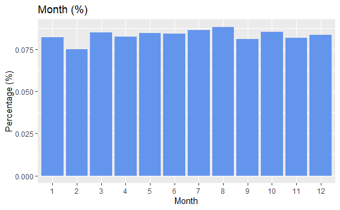

```r
# Percentage Distribution of Month
ggplot(merged_df, aes(x = Month)) +
  geom_bar(aes(y = (..count..)/sum(..count..)), fill = 'cornflowerblue') + ggtitle("Month (%)") +
  ylab("Percentage (%)")
```

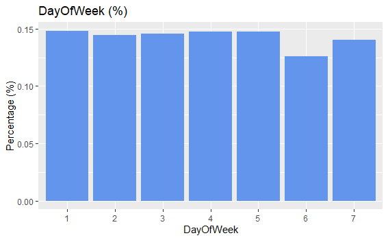

```r
# Percentage Distribution of DayOfWeek
ggplot(merged_df, aes(x = DayOfWeek)) +
  geom_bar(aes(y = (..count..)/sum(..count..)),fill = 'cornflowerblue') + ggtitle("DayOfWeek (%)") +
  ylab("Percentage (%)")
```

The data is almost evenly distributed between Month and DayOfWeek, with February and Saturday having the least number of total flights.

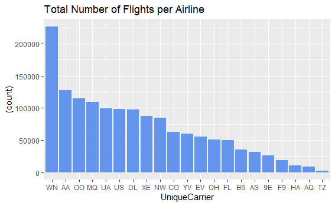

```r
#Total Number of flights per Airline
ggplot(merged_df, aes(x = forcats::fct_infreq(UniqueCarrier))) +
  geom_bar(aes(y = (..count..)),fill = 'cornflowerblue') + ggtitle("Total Number of Flights per Airline") +
  xlab("UniqueCarrier")
```

```r
carrier_df %>% filter_all(any_vars(. %in% c('WN', 'AA','OO','MQ','US')))
```

| Code | Description |
| --- | --- |
| AA | American Airlines Inc. |
| MQ | American Eagle Airlines Inc. |
| OO | Skywest Airlines Inc. |
| US | US Airways Inc. (Merged with America West 9/05. Reporting for both starting 10/07.) |
| WN | Southwest Airlines Co. |

The top 5 airlines with the most flights are WN, AA, OO, MQ, UA.

1. Southwest Airlines
2. American Airlines
3. Skywest Airlines
4. American Eagle Airlines
5. United Airlines

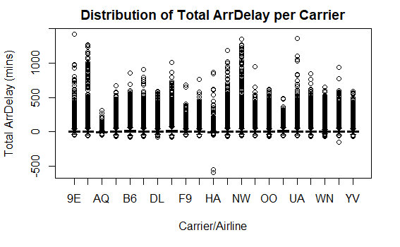

```r
#Boxplot Distribution of Total ArrDelay per Carrier
boxplot(flight_notcancelled$ArrDelay~flight_notcancelled$UniqueCarrier,
        main = "Distribution of Total ArrDelay per Carrier",
        xlab = "Carrier/Airline",
        ylab = "Total ArrDelay (mins)",
        border = "black"
        )
```

### Cancellation

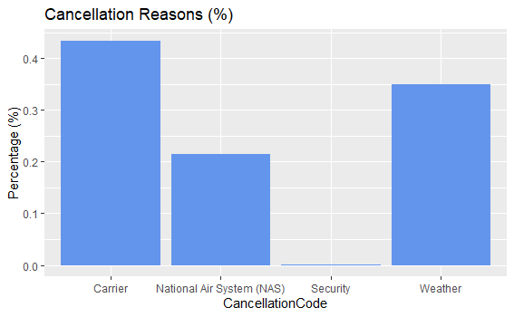

```r
# Percentage Distribution of Cancellation
ggplot(flight_cancelled, aes(x = CancellationCode)) +
  geom_bar(aes(y = (..count..)/sum(..count..)), fill = 'cornflowerblue') + ggtitle("Cancellation Reasons (%)") +
  ylab("Percentage (%)")
```

We can conclude that Cancellations are mostly due to Carrier, Weather and NAS with around 43%, 35% and 20% respectively.

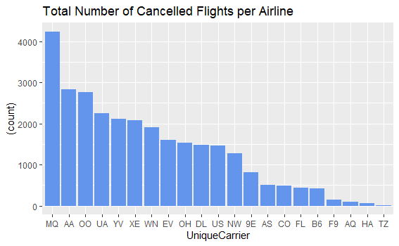

```r
#Total Number of Cancelled flights per Airline
ggplot(flight_cancelled, aes(x = forcats::fct_infreq(UniqueCarrier))) +
  geom_bar(aes(y = (..count..)),fill = 'cornflowerblue') + ggtitle("Total Number of Cancelled Flights per Airline") +
  xlab("UniqueCarrier")
```

```r
carrier_df %>% filter_all(any_vars(. %in% c('MQ', 'AA','OO')))
```

| Code | Description |
| --- | --- |
| AA | American Airlines Inc. |
| MQ | American Eagle Airlines Inc. |
| OO | Skywest Airlines Inc. |

The top 3 most cancelled flights throughout these 2 years are:

1. American Eagle Airlines
2. American Airlines
3. Skywest Airlines

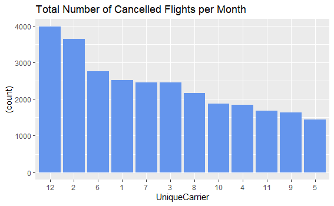

```r
#Total Number of Cancelled flights per Month
ggplot(flight_cancelled, aes(x = forcats::fct_infreq(Month))) +
  geom_bar(aes(y = (..count..)),fill = 'cornflowerblue') + ggtitle("Total Number of Cancelled Flights per Month") +
  xlab("UniqueCarrier")
```

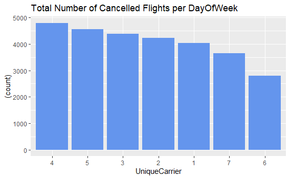

```r
#Total Number of Cancelled flights per DayOfWeek
ggplot(flight_cancelled, aes(x = forcats::fct_infreq(DayOfWeek))) +
  geom_bar(aes(y = (..count..)),fill = 'cornflowerblue') + ggtitle("Total Number of Cancelled Flights per DayOfWeek") +
  xlab("UniqueCarrier")
```

The flights are mostly likely to be cancelled in December and February, on a Thursday and Friday.

### Delay

```r
cor.test(flight_notcancelled$ArrDelay, flight_notcancelled$DepDelay, method = "pearson")
```

```
    Pearson's product-moment correlation

data:  flight_notcancelled$ArrDelay and flight_notcancelled$DepDelay
t = 2841.3, df = 1431016, p-value < 2.2e-16
alternative hypothesis: true correlation is not equal to 0
95 percent confidence interval:
 0.9213976 0.9218910
sample estimates:
      cor
0.9216447
```

ArrDelay and DepDelay have a strong positive linear relationship, implying that a Departure Delay will almost certainly result in an Arrival Delay.

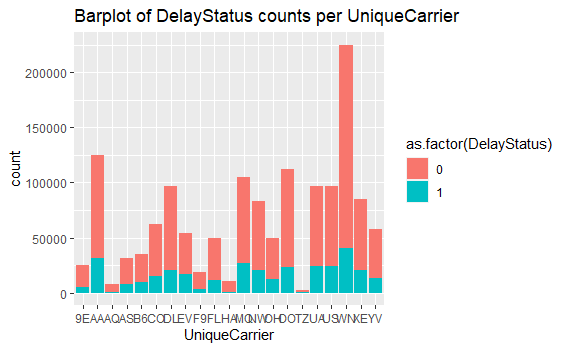

```r
# BarPlot
ggplot(flight_notcancelled, aes(x= UniqueCarrier)) + geom_bar(aes(fill=as.factor(DelayStatus))) + ggtitle("Barplot of DelayStatus counts per UniqueCarrier")
```

```r
carrier_df %>% filter_all(any_vars(. %in% c('WN', 'AA','OO')))
```

| Code | Description |
| --- | --- |
| AA | American Airlines Inc. |
| OO | Skywest Airlines Inc. |
| WN | Southwest Airlines Co. |

# Q1. When is the best time of day, day of the week, and time of year to fly to minimise delays?

- Best Time of the Day
- Best Day of the Week
- Best Month of the Year
- Best Day of the Month

## Best Time of the Day

### Distribution of Average Delay by Time Period

```r
# Create copy of dataframe
df_q1 <- flight_notcancelled
```

Time Intervals column ‘ArrPeriod’ was created based on ‘ArrTime’. 24 hours in a day will split into 6 different periods with at least 3 to 5-hour intervals since different timings like 5am and 11am are better not generalised together into a single timeframe. The period is split as such:

- Midnight (12am - 5am)
- Early Morning (5am - 9am)
- Late Morning (9am - 12pm)
- Afternoon (12pm - 5pm)
- Evening (5pm - 9pm)
- Night (9pm - 12am)

```r
# Categorising ArrTime and DepTime by 6 periods: Midnight, Early Morning, Late Morning, Afternoon, Evening, Night
df_q1 <- df_q1 %>%
  mutate(ArrPeriod = case_when(ArrTime >= 500 & ArrTime < 900 ~ 'Early Morning',
                          ArrTime >= 900 & ArrTime < 1200 ~ 'Late Morning',
                          ArrTime >= 1200 & ArrTime < 1700 ~ 'Afternoon',
                          ArrTime >= 1700 & ArrTime < 2100 ~ 'Evening',
                          ArrTime >= 2100 & ArrTime < 2400 ~ 'Night',
                          TRUE ~  'Midnight'))
```

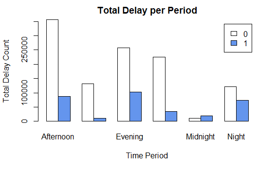

```r
# Create table counts
counts <- table(df_q1$DelayStatus,df_q1$ArrPeriod)

# Plot grouped barplot
barplot(counts, col = c("white","cornflowerblue"),
                       xlab = "Time Period", ylab = "Total Delay Count",
                       main = "Total Delay per Period",beside=TRUE,
                       legend = rownames(counts))
```

Early Morning followed by Midnight has the lowest count for number of flights delayed. However, we will proceed on to check if having the lowest number of count will equate to the shortest average delayed time.

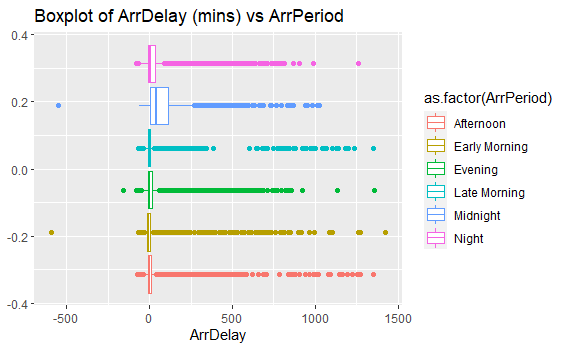

```r
# Boxplot
ggplot(df_q1, aes(x= ArrDelay)) + geom_boxplot(aes(color=as.factor(ArrPeriod))) + ggtitle("Boxplot of ArrDelay (mins) vs ArrPeriod")
```

The boxplot shows that the mean of ArrDelay for midnight is more than the other time period. Hence, validating our assumption that lowest flight delay counts does not equate to lowest average delayed time.

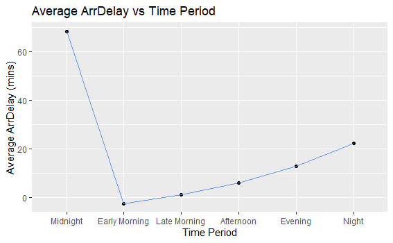

```r
#Set Sequence to ArrPeriod
df_q1$ArrPeriod <- factor(df_q1$ArrPeriod,levels = c("Midnight", "Early Morning", "Late Morning", "Afternoon", "Evening", "Night"))

df_q1  %>% group_by(ArrPeriod) %>% dplyr::summarize(mean = mean(ArrDelay)) %>%
  ggplot(aes(x= ArrPeriod, y = mean)) +
  geom_point() +
  geom_line(aes(group = 1), col = "cornflowerblue") + ggtitle("Average ArrDelay vs Time Period") +
  xlab("Time Period") + ylab("Average ArrDelay (mins)")
```

The best time period to minimise flight delays would be in the Early Morning from 5am to 9am.

## Best Day of the Week

### Distribution of Day Delay

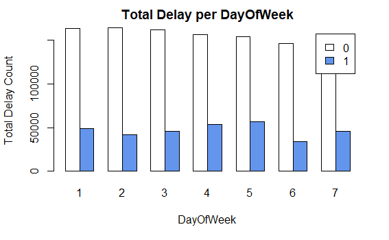

```r
# Create table for counts
counts <- table(df_q1$DelayStatus,df_q1$DayOfWeek)
# Plot grouped barplot
barplot(counts, col = c("white","cornflowerblue"),
                       xlab = "DayOfWeek",ylab = "Total Delay Count",
                       main = "Total Delay per DayOfWeek",beside=TRUE,
                       legend = rownames(counts))
```

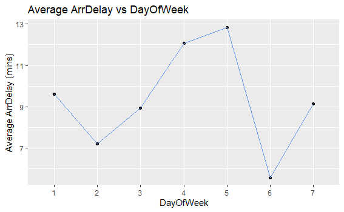

```r
#Line Plot
df_q1  %>% group_by(DayOfWeek) %>% dplyr::summarize(mean = mean(ArrDelay)) %>%
  ggplot(aes(x= DayOfWeek, y = mean)) +
  geom_point() +
  geom_line(aes(group = 1), col = "cornflowerblue") + ggtitle("Average ArrDelay vs DayOfWeek") +
  xlab("DayOfWeek") + ylab("Average ArrDelay (mins)")
```

The Best Day of the Week to minimize delays is to travel on Saturday, followed by Tuesday, with average ArrDelay timing of less than 6 minutes and 8 minutes, respectively.

The longest average delays of 12-13 minutes are expected in the middle of the week, from Thursday to Friday.

## Best Month of the Year

### Distribution of Monthly Delay

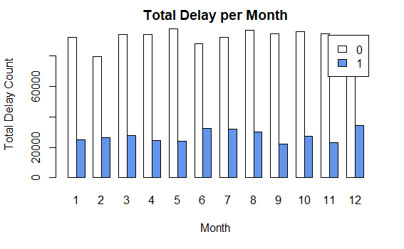

```r
# create table counts
counts <- table(df_q1$DelayStatus,df_q1$Month)
# Plot grouped barplot
barplot(counts, col = c("white","cornflowerblue"),
                       xlab = "Month",ylab = "Total Delay Count",
                       main = "Total Delay per Month",beside=TRUE,
                       legend = rownames(counts))
```

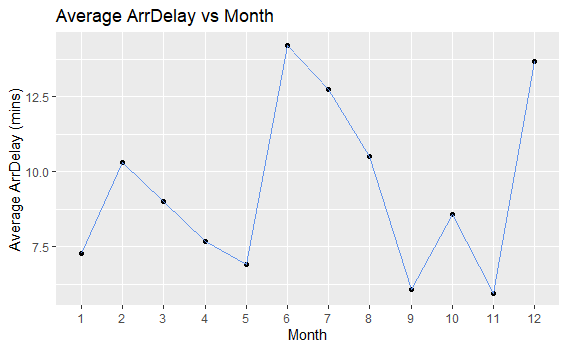

```r
df_q1 %>% group_by(Month) %>% dplyr::summarize(mean = mean(ArrDelay)) %>%
  ggplot(aes(x= Month, y = mean)) +
  geom_point() +
  geom_line(aes(group = 1), col = "cornflowerblue") + ggtitle("Average ArrDelay vs Month") +
  xlab("Month") + ylab("Average ArrDelay (mins)")
```

Based on ArrDelay, the best time of year to minimise travel delay is November, then September, with both averaging approximately 6 minutes of delay, as opposed to June and December, with more than twice the number of minutes delayed.

Due to the U.S. summer and winter vacation (School Holidays USA, 2022), June and December are projected to be popular months to travel.